# RACEPLUS - Sample size. Analisi intermedi

Author

Jordi Cortés Martínez

Published

3/25/25

## Resum executiu

S’ha de fer un anàlisi intermedi a la meitat de l’estudi (**n = 1750**) i s’ha de trobar una diferència de proporcions de **0.025** per tenir una probabilitat del **80%** de detectar diferències entre els dos algoritmes al final de l’estudi.

## Raonament

1. Es vol fer un anàlisi intermedi per avaluar si l’algoritme del RACEPLUS està funcionant millor que l’escala RACE respecte a la variable principal que és predir els ictus amb LVO.
1. No és una anàlisi intermedi ni d’eficàcia ni de futilitat ja que no s’aturarà l’estudi en cap cas.
2. La única decisió que es prendrà serà si continuar amb l’algoritme actual del RACEPLUS o canviar a algun altre variant de l’algoritme inicial (p.ex. atorgant pesos als individus)
2. Com que no s’aturarà l’estudi, el càlcul de la mida mostral no s’ha de fer en base a corregir els errors de tipus I o de tipus II sinó en base a tenir un criteri per concloure si val la pena canviar d’algoritme o no. Es pot fer de diverses maneres:
1. **Enfoc freqüentista**. Fent una comparació de proporció aparellada (McNemar test) i demanant que la proporció d’encerts del RACEPLUS per LVO sigui almenys XXX% superior als encerts amb l’escala RACE. Com que sabem la distribució de l’estadístic, podríem fer el càlcul de la mida mostral. Inconvenient: El càlcul total de la mida mostral està pensat per demostrar superioritat assumint que el XXX% de diferència en els encerts és molt baix i, per tant, no tindrem potència per demostrar-ho.
2. **Enfoc Bayesià**. Estimar la distribució a posteriori de la diferència de proporcions aparellada emprant l’aproximació per la Normal de la diferència de proporcions d’encerts. El càlcul de la mida mostral es faria en base a demostrar que la probabilitat de que RACEPLUS encerti més que RACE és major al 50%. Inconvenient: Manca d’experiència en aquest anàlisi i que s’ha d’assumir coneguda la mitjana o la variància. Nota: No es pot estimar les distribucions a posteriori de les dues probabilitats d’encert per separat (amb RACE i RACEPLUS) ja que no són mostres independents. Seria més fàcil fer-ho així emprant Beta com a priori i Betabinomial com a posteriori.
3. **Enfoc per simulació/Bayesià**. Extrapolar quina és la probabilitat de que al final s’assoleixi l’objectiu de demostrar que RACEPLUS és millor que RACE. Calcular per simulació les diferències observades a l’intermedi amb diferents grandàries mostrals i diferents proporcions reals i recollir en que desencadenen al final. Incovenient: cost computacional. Per calcular la probabilitat d’èxit es necessita igualment l’enfoc bayesià.

## Mètodes

Es fan els següents passos:

1. **PARAMETRES**. Estimar paràmetres bàsics de RACE i RACEPLUS. Basant-nos en dades històriques, estimem:
- Probabilitat d’èxit per predir LVO per cada algoritme ($\hat{p}_{RACE} \approx 0.67$, $\hat{p}_{RACEPLUS} \approx 0.69$)
- Correlació entre els encerts. ($\hat{\rho} \approx 0.58$)
2. **A PRIORI**. S’estima una distribució a priori per la diferència de proporcions tenint fent servir l’aproximació Normal.

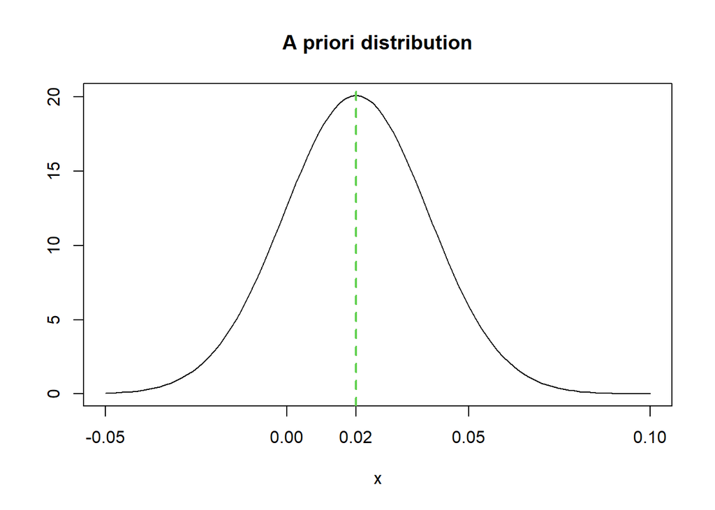

3. **SIMULACIÓ**. Es fa una simulació ($nsim=10000$) on es generen dades d’encerts/errades en l’anàlisi intermedi tenint en compte diferents escenaris:

**ESCENARIS:**

Combinacions de:

1. La diferència real en encerts entre RACEPLUS i RACE ($\Delta \in \{-0.01,-0.005,0,0.005,0.01,0.015,0.02,0.025,0.03\}$)
2. La mida mostral considerada en l’interim analysis ($SS \in \{350 875 1155 1750\}$). Aquests valors es correponen a un 10%, 25%, 33% i 50% de la mida mostral total ($n = 3500$)

**OUTCOMES RECOLLITS:**

1. P-valor de l’estadístic de McNemar per comparació de proporcions aparellades a l’interim i al final de l’estudi
2. Diferència de proporció d’encerts a l’interim i al final de l’estudi
3. Límit inferior de l’interval de confinça del 95% per la diferència de proporció d’encerts a l’interim i al final de l’estudi
4. **PROBABILITAT d’ÈXIT**. Es calcula la probabilitat d’èxit al final de l’estudi depenent de la mida mostral de l’interim i el punt de tall per la diferència de proporcions. L’èxit es defineix com poder demostrar al final de l’estudi que la proporció d’enerts del RACEPLUS és major que la del RACE.
1. S’aplica la llei de probabilitat totals: $P(EXIT|cutpoint = c) = \sum_{i} \left[ P(EXIT|cutpoint = c \; \cap \; \Delta= \delta_i) · P(\Delta= \delta_i) \right]$
2. La part $P(EXIT|cutpoint = c \; \cap \; \Delta= \delta_i)$ s’obté a partir de la simulació mirant la proporció d’èxits entre aquells casos on l’anàlisi intermedi es sobrepasa el punt de tall $c$ en la diferència de probabilitats.
3. La part $P(\Delta= \delta_i)$ s’obté de la funció de densitat a priori estandaritzada.

D’aquesta forma, per cada punt de tall $c$ i cada grandària mostral, podem tenir la probabilitat d’èxit.

*Nota*: La llei de probabilitat totals estrictament s’hauria de aplicar en format continu.

## Resultats

La següent figura mostra els resultats principals per quatre grandàries a l’interim (*ss_int*) diferents.

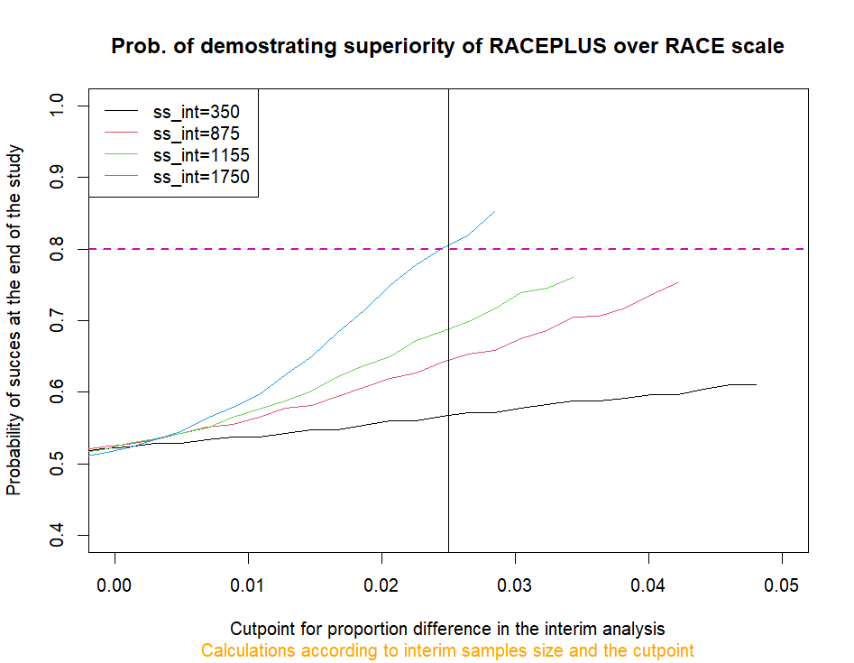

sample size

Per tenir una probabilitat d’almenys el 80% (linea puntejada horitzontal) de demostrar la superioritat de RACEPLUS sobre RACE necessitem fem un anaàlisi intermedi a la meitat de l’estudi (n = 1750) i posar un punt de tall de 0.025 (línea vertical) en la diferència de proporcions entre ambdós mètodes predictius. En cas contrari, s’hauria de canviar d’algoritme en aquest anàlis intermedi.

## Apendix I: Codi d’anàlisi

El codi d’anàlisi es troba [aquí](https://github.com/jordicortes40/sample_size_RACEPLUS).